## Faculty of Economic Sciences University of Warsaw

Machine Learning 1: Classification Methods\ Dr. Maciej Wilamowski

# Used Car Price Prediction Analysis

Huseyin Can Minareci & Noam Shmuel

# Introduction

In this project, we aim to find the best regression model for dataset in order to be able to predict used cars prices.\ We have used public dataset from Kaggle which was scraped with Scrapy by Orges Leka from Ebay-Kleinanzeigen. It contains more than 370000 cars and 20 features of each of them like price, power, model etc...\ Original dataset had plenty missing values, outliers and mistakes, to be able to work on it we had to clean, impute and change their format.\ We select the features carefully and extract new features from raw data.\ In order to achieve this goal we used Linear Model, K Nearest Neighbor and Random Forest.

# Data Preparation

```python
# Importing the packages which we are going to use
import pandas as pd
import numpy as np
import math
import random
import time
import matplotlib
from math import sqrt
import matplotlib.pyplot as plt
import seaborn as sns
from sklearn import datasets, linear_model, preprocessing, svm, neighbors, metrics
from sklearn.preprocessing import StandardScaler, Normalizer, MinMaxScaler
from datetime import datetime
import statsmodels.api as sm
import statsmodels.formula.api as smf
from sklearn.metrics import mean_squared_error, r2_score
from sklearn.linear_model import LinearRegression
from sklearn.tree import DecisionTreeRegressor
from sklearn.ensemble import RandomForestRegressor
from sklearn.model_selection import KFold, train_test_split, GridSearchCV

%matplotlib inline
```

```python
# reading dataset
df = pd.read_csv('autos.csv', sep=',', header=0, encoding='cp1252')
df.sample(5)
```

|  | dateCrawled | name | seller | offerType | price | abtest | vehicleType | yearOfRegistration | gearbox | powerPS | model | kilometer | monthOfRegistration | fuelType | brand | notRepairedDamage | dateCreated | nrOfPictures | postalCode | lastSeen |
| --- | --- | --- | --- | --- | --- | --- | --- | --- | --- | --- | --- | --- | --- | --- | --- | --- | --- | --- | --- | --- |
| 158581 | 2016-03-30 17:57:54 | cosa_c_mod.2001_navi_klima_125tkm | privat | Angebot | 1000 | control | kleinwagen | 2000 | manuell | 75 | corsa | 125000 | 11 | benzin | opel | nein | 2016-03-30 00:00:00 | 0 | 44866 | 2016-03-30 17:57:54 |
| 365852 | 2016-03-26 18:56:39 | Nissan_Qashqai+2_1.5_dCi_DPF_visia | privat | Angebot | 10960 | test | limousine | 2010 | manuell | 103 | qashqai | 125000 | 6 | diesel | nissan | nein | 2016-03-26 00:00:00 | 0 | 53125 | 2016-03-26 18:56:39 |
| 367316 | 2016-03-12 12:58:01 | Ford_Ka_kleinwagen_60_Ps | privat | Angebot | 400 | test | kleinwagen | 1996 | manuell | 60 | ka | 50000 | 12 | benzin | ford | NaN | 2016-03-12 00:00:00 | 0 | 85551 | 2016-03-17 12:17:36 |
| 104784 | 2016-03-09 12:47:42 | Mercedes_Benz_A_140_Classic | privat | Angebot | 1900 | control | limousine | 1999 | automatik | 82 | a_klasse | 150000 | 9 | benzin | mercedes_benz | nein | 2016-03-09 00:00:00 | 0 | 67378 | 2016-03-10 08:16:22 |
| 187527 | 2016-03-11 17:39:12 | Mazda_CX_7_2.2_MZR_CD_Exclusive___Line_/_SUV | privat | Angebot | 16500 | control | suv | 2009 | NaN | 0 | cx_reihe | 90000 | 10 | diesel | mazda | nein | 2016-03-11 00:00:00 | 0 | 77749 | 2016-04-05 17:17:01 |

#### The variables explained as follows:

price : the price on the advert to sell the car, This is the dependent variable in all of the upcoming models.\ dateCrawled : when advert was first crawled, all field-values are taken from this date\ name : headline, which the owner of the car gave to the advert\ seller : who is selling the car(private or dealer)\ offerType : offer(car to sell) or request(car to buy)\

abtest : ebay-intern variable (a/b testing)\ vehicleType : one of eight vehicle-categories \ yearOfRegistration : at which year the car was first registered\ gearbox : manual or automatic\ powerPS : the power of the car in PS\

model : the car's model\ kilometer : how many kilometres the car has driven\ monthOfRegistration : at which month the car was first registered\ fuelType : one of seven fuel-categories\ brand : the car's brand\

notRepairedDamage : if the car has a damage which is not repaired yet\ dateCreated : the date for which the advert at 'ebay Kleinanzeigen' was created\ nrOfPictures : number of pictures in the advert\ postalCode : where in germany the car is located\ lastSeenOnline : when the crawler saw this advert last online

### Duplicates and outliers

Since data is crawled by scraper we may have some duplicates it will be better to check and drop them as first step.

```python
# Removing the duplicates
dfl = df.drop_duplicates(['name','price','vehicleType','yearOfRegistration'
                         ,'gearbox','powerPS','model','kilometer','monthOfRegistration','fuelType'
                         ,'notRepairedDamage'])
left = 100 * dfl['name'].count() / df['name'].count()
print("The amount of data left:", left, "%")
```

```
The amount of data left: 97.64270795202515 %
```

```python
df.describe()
```

|  | price | yearOfRegistration | powerPS | kilometer | monthOfRegistration | nrOfPictures | postalCode |
| --- | --- | --- | --- | --- | --- | --- | --- |
| count | 3.715280e+05 | 371528.000000 | 371528.000000 | 371528.000000 | 371528.000000 | 371528.0 | 371528.00000 |
| mean | 1.729514e+04 | 2004.577997 | 115.549477 | 125618.688228 | 5.734445 | 0.0 | 50820.66764 |
| std | 3.587954e+06 | 92.866598 | 192.139578 | 40112.337051 | 3.712412 | 0.0 | 25799.08247 |
| min | 0.000000e+00 | 1000.000000 | 0.000000 | 5000.000000 | 0.000000 | 0.0 | 1067.00000 |
| 25% | 1.150000e+03 | 1999.000000 | 70.000000 | 125000.000000 | 3.000000 | 0.0 | 30459.00000 |
| 50% | 2.950000e+03 | 2003.000000 | 105.000000 | 150000.000000 | 6.000000 | 0.0 | 49610.00000 |
| 75% | 7.200000e+03 | 2008.000000 | 150.000000 | 150000.000000 | 9.000000 | 0.0 | 71546.00000 |
| max | 2.147484e+09 | 9999.000000 | 20000.000000 | 150000.000000 | 12.000000 | 0.0 | 99998.00000 |

It can be clearly seen from summary statistics that there are outliers(yearOfRegistration, powerPS, price) in the data. We should remove them in order to continue.

```python
print("Cars more expensive than 40000:", (dfl.price > 40000).sum())
print("Cars cheaper than 250:",(dfl.price < 250).sum())
print("Cars which has less than 10PS:" , (dfl.powerPS < 10).sum())
print("Cars which has more than 400PS:" , (dfl.powerPS > 400).sum())
print("Cars newer than 2017:" , (dfl.yearOfRegistration >= 2017).sum())
print("Cars older than 1990:" , (dfl.yearOfRegistration < 1990).sum())
```

```
Cars more expensive than 40000: 2692
Cars cheaper than 250: 19530
Cars which has less than 10PS: 39579
Cars which has more than 400PS: 1864
Cars newer than 2017: 14483
Cars older than 1990: 10495
```

There are only 2692 cars which are more expensive than 40000 since we have over 370000 cars we can easily call them as outliers and remove them from our dataset. Also we don't want to take into account the obvious mistakes like cars cheaper than 250. \

Looks like we have a lot of cars which has 0 PS since something like that it is not possible we need to remove them from our dataset as well.

```python
# Removing the outliers
dfl = dfl[
        (dfl.yearOfRegistration <= 2017)
      & (dfl.yearOfRegistration >= 1990)
      & (dfl.price >= 250)
      & (dfl.price <= 40000)
      & (dfl.powerPS >= 10)
      & (dfl.powerPS <= 400)]
left = 100 * dfl['name'].count() / df['name'].count()
print("The amount of data left:", left, "%")
```

```
The amount of data left: 79.97378394091427 %
```

We check again summary statistics to see if outliers removed from dataset succesfully.

```python
dfl.describe()
```

|  | price | yearOfRegistration | powerPS | kilometer | monthOfRegistration | nrOfPictures | postalCode |
| --- | --- | --- | --- | --- | --- | --- | --- |
| count | 297125.000000 | 297125.000000 | 297125.000000 | 297125.000000 | 297125.000000 | 297125.0 | 297125.000000 |
| mean | 5805.787638 | 2004.062714 | 124.808094 | 126377.063525 | 6.016505 | 0.0 | 51641.176182 |
| std | 6364.402007 | 5.932930 | 55.794467 | 38409.786388 | 3.577724 | 0.0 | 25686.994168 |
| min | 250.000000 | 1990.000000 | 10.000000 | 5000.000000 | 0.000000 | 0.0 | 1067.000000 |
| 25% | 1450.000000 | 2000.000000 | 82.000000 | 125000.000000 | 3.000000 | 0.0 | 31246.000000 |
| 50% | 3499.000000 | 2004.000000 | 116.000000 | 150000.000000 | 6.000000 | 0.0 | 50765.000000 |
| 75% | 7800.000000 | 2008.000000 | 150.000000 | 150000.000000 | 9.000000 | 0.0 | 72393.000000 |
| max | 40000.000000 | 2017.000000 | 400.000000 | 150000.000000 | 12.000000 | 0.0 | 99998.000000 |

### Exploratory Data Analysis

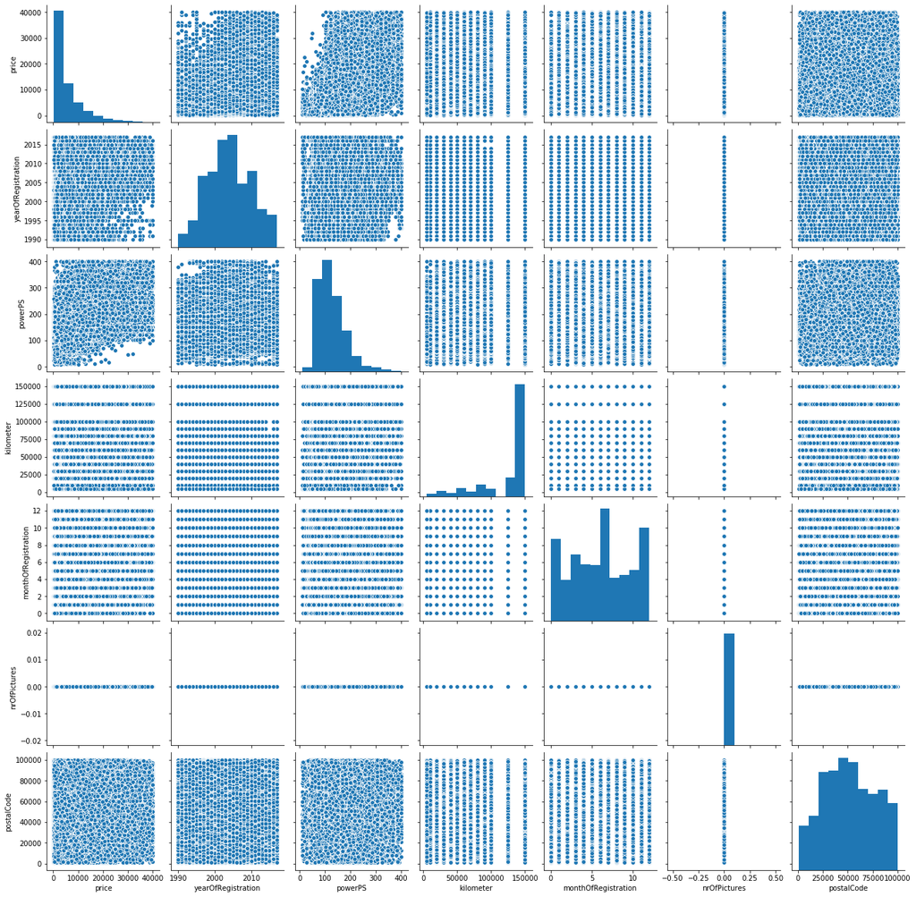

```python
sns.pairplot(dfl)
```

From pairwise plots we can see how our variables looks like and go deeper to the necessary ones.

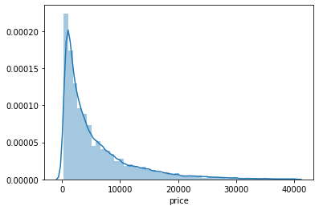

```python
sns.distplot(dfl["price"])
```

We have make a log transformation on price in in order to get rid of right skewness.

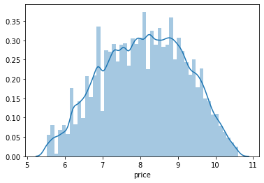

```python
dfl['priceNormal'] = dfl['price']
dfl['price'] = np.log(dfl['price'])
sns.distplot(dfl["price"])
```

Since we did log transformation to our dependent variable we need to do also to the skewed independent variables

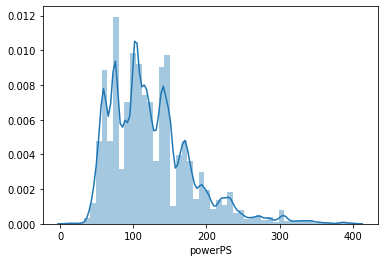

```python
sns.distplot(dfl["powerPS"])
```

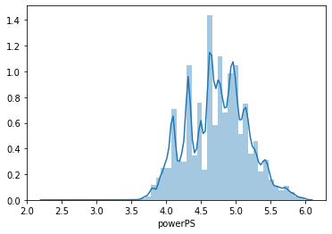

```python
dfl['powerPS'] = np.log(dfl['powerPS'])
sns.distplot(dfl["powerPS"])
```

## Feature Engineering & Selection

After dealing with duplicates, outliers and transformation, we moved to the next part; Feature Engineering.

### daysBeforeSold

```python
dfl.loc[:,("dateCrawled", "dateCreated", "postalCode", "lastSeen")]
```

|  | dateCrawled | dateCreated | postalCode | lastSeen |
| --- | --- | --- | --- | --- |
| 1 | 2016-03-24 10:58:45 | 2016-03-24 00:00:00 | 66954 | 2016-04-07 01:46:50 |
| 2 | 2016-03-14 12:52:21 | 2016-03-14 00:00:00 | 90480 | 2016-04-05 12:47:46 |
| 3 | 2016-03-17 16:54:04 | 2016-03-17 00:00:00 | 91074 | 2016-03-17 17:40:17 |
| 4 | 2016-03-31 17:25:20 | 2016-03-31 00:00:00 | 60437 | 2016-04-06 10:17:21 |
| 5 | 2016-04-04 17:36:23 | 2016-04-04 00:00:00 | 33775 | 2016-04-06 19:17:07 |
| ... | ... | ... | ... | ... |
| 371520 | 2016-03-19 19:53:49 | 2016-03-19 00:00:00 | 96465 | 2016-03-19 20:44:43 |
| 371524 | 2016-03-05 19:56:21 | 2016-03-05 00:00:00 | 26135 | 2016-03-11 18:17:12 |
| 371525 | 2016-03-19 18:57:12 | 2016-03-19 00:00:00 | 87439 | 2016-04-07 07:15:26 |
| 371526 | 2016-03-20 19:41:08 | 2016-03-20 00:00:00 | 40764 | 2016-03-24 12:45:21 |
| 371527 | 2016-03-07 19:39:19 | 2016-03-07 00:00:00 | 73326 | 2016-03-22 03:17:10 |

297125 rows × 4 columns

We don't think "dateCrawled" and "postalCode" would be useful for price prediction so we decided to remove them.\ Although "dateCreated" and "lastSeen" could be useful if can be modified as how many days advert was on the site before it sold.(or removed)

```python
dfl = dfl.drop(["dateCrawled", "postalCode"], axis='columns')
```

In the dataset dateCreated and lastSeen is in string format. In order get the days we choosed to change the format to timestamp.

Since we can use substraction in timestamp, we substract dateCreated from lastSeen.

And finally take just take the day since we don't need hours minutes and seconds in our models.

```python
# creating funtion to change string to timestamp
def changeformat(date):
    datefr = datetime.strptime(date, '%Y-%m-%d %H:%M:%S')
    return datefr
```

```python
dfl["dateCreated"] = dfl["dateCreated"].apply(changeformat)
dfl["lastSeen"] = dfl["lastSeen"].apply(changeformat)
dfl["diff"] = dfl["lastSeen"]-dfl["dateCreated"]
dfl["daysBeforeSold"] = dfl["diff"].apply((lambda x: x.days))
```

```python
dfl.loc[:,("dateCreated", "lastSeen", "diff", "daysBeforeSold")]
```

|  | dateCreated | lastSeen | diff | daysBeforeSold |
| --- | --- | --- | --- | --- |
| 1 | 2016-03-24 | 2016-04-07 01:46:50 | 14 days 01:46:50 | 14 |
| 2 | 2016-03-14 | 2016-04-05 12:47:46 | 22 days 12:47:46 | 22 |
| 3 | 2016-03-17 | 2016-03-17 17:40:17 | 0 days 17:40:17 | 0 |
| 4 | 2016-03-31 | 2016-04-06 10:17:21 | 6 days 10:17:21 | 6 |
| 5 | 2016-04-04 | 2016-04-06 19:17:07 | 2 days 19:17:07 | 2 |
| ... | ... | ... | ... | ... |
| 371520 | 2016-03-19 | 2016-03-19 20:44:43 | 0 days 20:44:43 | 0 |
| 371524 | 2016-03-05 | 2016-03-11 18:17:12 | 6 days 18:17:12 | 6 |
| 371525 | 2016-03-19 | 2016-04-07 07:15:26 | 19 days 07:15:26 | 19 |
| 371526 | 2016-03-20 | 2016-03-24 12:45:21 | 4 days 12:45:21 | 4 |
| 371527 | 2016-03-07 | 2016-03-22 03:17:10 | 15 days 03:17:10 | 15 |

297125 rows × 4 columns

After succesfully getting the day difference in integer format we removed "dateCreated", "lastSeen" and "diff" from the data.

```python
dfl = dfl.drop(["dateCreated", "lastSeen", "diff"], axis='columns')
```

### namelen

```python
dfl["name"]
```

```
1                                      A5_Sportback_2.7_Tdi
2                            Jeep_Grand_Cherokee_"Overland"
3                                        GOLF_4_1_4__3TÜRER
4                            Skoda_Fabia_1.4_TDI_PD_Classic
5         BMW_316i___e36_Limousine___Bastlerfahrzeug__Ex...
                                ...
371520                                         turbo_defekt
371524                Smart_smart_leistungssteigerung_100ps
371525                   Volkswagen_Multivan_T4_TDI_7DC_UY2
371526                               VW_Golf_Kombi_1_9l_TDI
371527         BMW_M135i_vollausgestattet_NP_52.720____Euro
Name: name, Length: 297125, dtype: object
```

Names of adverts are not usefull how they are right now we want to try to get something from this.

Taking their length and checking if it would be helpful in our prediction sounded like it worths to give it a try.

```python
dfl['namelen'] = [min(70, len(n)) for n in dfl['name']]
```

```python
dfl.loc[:,'namelen']
```

```
1         20
2         30
3         18
4         30
5         50
          ..
371520    12
371524    37
371525    34
371526    22
371527    44
Name: namelen, Length: 297125, dtype: int64
```

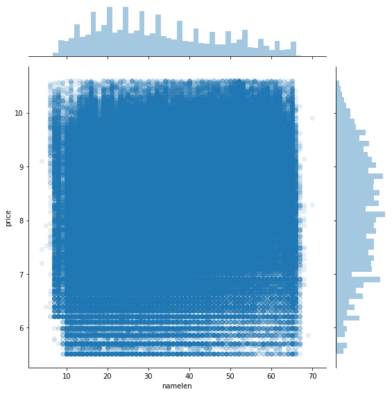

```python
sns.jointplot(x='namelen',
                   y='price',
                   data=dfl[['namelen','price']],
                    alpha=0.1,
                    height=8)
```

It seems that a name length can help us to predict the price since it looks like there is some connection between them.

Longer the name is more expensive the car, it can be because the cars with additional features would take longer to describe them. From other side shorter the explanation can lead us to think that car doesn't have much to write about that's why it's cheaper.

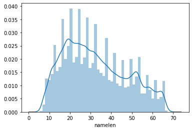

```python
sns.distplot(dfl.namelen)
```

We droped the name column since we took length of it.

```python
dfl = dfl.drop(["name"], axis='columns')
```

### Age

Instead of dealing with years we create "age" of the car by using yearOfRegistration and simply substacting it from 2017(the year data collected)

```python
dfl["age"] = dfl["yearOfRegistration"].apply((lambda x: max(0, 2017-x)))
```

```python
dfl.describe()
```

|  | price | yearOfRegistration | powerPS | kilometer | monthOfRegistration | nrOfPictures | priceNormal | daysBeforeSold | namelen | age |
| --- | --- | --- | --- | --- | --- | --- | --- | --- | --- | --- |
| count | 297125.000000 | 297125.000000 | 297125.000000 | 297125.000000 | 297125.000000 | 297125.0 | 297125.000000 | 297125.000000 | 297125.000000 | 297125.000000 |
| mean | 8.107775 | 2004.062714 | 4.733331 | 126377.063525 | 6.016505 | 0.0 | 5805.787638 | 9.059598 | 32.280074 | 12.937286 |
| std | 1.110681 | 5.932930 | 0.433482 | 38409.786388 | 3.577724 | 0.0 | 6364.402007 | 8.629988 | 15.048183 | 5.932930 |
| min | 5.521461 | 1990.000000 | 2.302585 | 5000.000000 | 0.000000 | 0.0 | 250.000000 | 0.000000 | 4.000000 | 0.000000 |
| 25% | 7.279319 | 2000.000000 | 4.406719 | 125000.000000 | 3.000000 | 0.0 | 1450.000000 | 2.000000 | 20.000000 | 9.000000 |
| 50% | 8.160232 | 2004.000000 | 4.753590 | 150000.000000 | 6.000000 | 0.0 | 3499.000000 | 6.000000 | 30.000000 | 13.000000 |
| 75% | 8.961879 | 2008.000000 | 5.010635 | 150000.000000 | 9.000000 | 0.0 | 7800.000000 | 14.000000 | 43.000000 | 17.000000 |
| max | 10.596635 | 2017.000000 | 5.991465 | 150000.000000 | 12.000000 | 0.0 | 40000.000000 | 384.000000 | 70.000000 | 27.000000 |

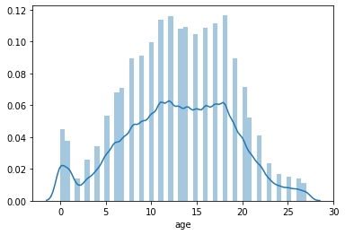

```python
sns.distplot(dfl["age"])
```

Since we have age of the car we drop yearOfRegistration and monthOfRegistration.

```python
dfl = dfl.drop(["yearOfRegistration", "monthOfRegistration"], axis='columns')
```

### gearbox abtest notRepairedDamage

```python
print(dfl.gearbox.value_counts())
print(dfl.abtest.value_counts())
print(dfl.notRepairedDamage.value_counts())
```

```
manuell      227724
automatik     64153
Name: gearbox, dtype: int64
test       153806
control    143319
Name: abtest, dtype: int64
nein    228640
ja       26457
Name: notRepairedDamage, dtype: int64
```

We decided to keep gearbox and notRepairedDamage since they differ among the dataset and could be useful for model\ Although abtest is A/B testing(user experience research) of eBay, so we decided to drop it.

```python
dfl = dfl.drop(["abtest"], axis='columns')
```

### offerType nrOfPictures seller

```python
print(dfl.offerType.value_counts())
print(dfl.nrOfPictures.value_counts())
print(dfl.seller.value_counts())
```

```
Angebot    297123
Gesuch          2
Name: offerType, dtype: int64
0    297125
Name: nrOfPictures, dtype: int64
privat        297124
gewerblich         1
Name: seller, dtype: int64
```

Since there are just 2 unique values and 1-2 value in second ones in seller and offerType we decided to drop them.

If it comes to nrOfPictures looks like there was a problem with scrawler and we have only zeros. That's why we have to drop them since it will not help to us how it is right now and there is no way to predict it at the moment.

```python
dfl = dfl.drop(["offerType", "nrOfPictures", "seller"], axis='columns')
```

```python
dfl.head(10)
```

|  | price | vehicleType | gearbox | powerPS | model | kilometer | fuelType | brand | notRepairedDamage | priceNormal | daysBeforeSold | namelen | age |
| --- | --- | --- | --- | --- | --- | --- | --- | --- | --- | --- | --- | --- | --- |
| 1 | 9.814656 | coupe | manuell | 5.247024 | NaN | 125000 | diesel | audi | ja | 18300 | 14 | 20 | 6 |
| 2 | 9.190138 | suv | automatik | 5.093750 | grand | 125000 | diesel | jeep | NaN | 9800 | 22 | 30 | 13 |
| 3 | 7.313220 | kleinwagen | manuell | 4.317488 | golf | 150000 | benzin | volkswagen | nein | 1500 | 0 | 18 | 16 |
| 4 | 8.188689 | kleinwagen | manuell | 4.234107 | fabia | 90000 | diesel | skoda | nein | 3600 | 6 | 30 | 9 |
| 5 | 6.476972 | limousine | manuell | 4.624973 | 3er | 150000 | benzin | bmw | ja | 650 | 2 | 50 | 22 |
| 6 | 7.696213 | cabrio | manuell | 4.691348 | 2_reihe | 150000 | benzin | peugeot | nein | 2200 | 4 | 27 | 13 |
| 8 | 9.581904 | bus | manuell | 4.828314 | c_max | 30000 | benzin | ford | NaN | 14500 | 0 | 36 | 3 |
| 9 | 6.906755 | kleinwagen | manuell | 4.615121 | golf | 150000 | NaN | volkswagen | NaN | 999 | 14 | 53 | 19 |
| 10 | 7.600902 | limousine | manuell | 4.653960 | 3_reihe | 150000 | benzin | mazda | nein | 2000 | 11 | 17 | 13 |
| 11 | 7.937017 | kombi | manuell | 4.941642 | passat | 150000 | diesel | volkswagen | ja | 2799 | 0 | 45 | 12 |

### Translating data from German to English

Since we finished feature engineering and selection before moving to dealing with missing values we translate data from German to English.

```python
## translate data from german to english
dfl['gearbox'] = dfl['gearbox'].replace(to_replace=['automatik', 'manuell'], value=['automatic', 'manual'], inplace=False, limit=None)
dfl['fuelType'] = dfl['fuelType'].replace(to_replace=['andere', 'benzin', 'elektro'], value=['others', 'petrol', 'electric'], inplace=False, limit=None)
dfl['vehicleType'] = dfl['vehicleType'].replace(to_replace=['andere', 'kombi', 'kleinwagen'], value=['others', 'station wagon', 'small car'], inplace=False, limit=None)
dfl['notRepairedDamage'] = dfl['notRepairedDamage'].replace(to_replace=['ja', 'nein'], value=['yes', 'no'], inplace=False, limit=None)
dfl['brand'] = dfl['brand'].replace(to_replace = ["sonstige_autos"], value=["other"], inplace=False, limit=None)
```

## Missing values

We have removed problematic values like duplicates and outliers, after that we have chosed the features we are going to work with and drop the rest. Now we are going to deal with missing values in the dataset.

```python
dfdpna = dfl.copy()
dfdpna = dfdpna.dropna()

missing = 100 - 100 * dfdpna['price'].count() / dfl['price'].count()
print("Missing values:", missing, "%")
```

```
Missing values: 21.833235170382835 %
```

It looks like around 22% of the data has missing values.

## Imputation

We decided to investigate every column with missing values one by one and see how we can deal with them.

```python
dfim = dfl.copy()
```

```python
dfim.isnull().sum()
```

```
price                    0
vehicleType          17107
gearbox               5248
powerPS                  0
model                10686
kilometer                0
fuelType             16998
brand                    0
notRepairedDamage    42028
priceNormal              0
daysBeforeSold           0
namelen                  0
age                      0
dtype: int64
```

### vehicleType

vehicleType has 17107 missing values.

This column there are 8 categorical values and their distribution looks like as it follows.

```python
dfim['vehicleType'].value_counts()
```

```
limousine        80872
small car        65554
station wagon    58854
bus              26371
cabrio           19283
coupe            14652
suv              12267
others            2165
Name: vehicleType, dtype: int64
```

We checked the mean of every group in order to do some meaningful imputation.

```python
dfim.groupby(['vehicleType']).priceNormal.mean()
```

```
vehicleType
bus               6713.635547
cabrio            8792.936213
coupe             8559.776754
limousine         5987.652265
others            4219.128868
small car         3047.271867
station wagon     5968.634859
suv              12458.418032
Name: priceNormal, dtype: float64
```

After seeing difference in the average prices we decided to create a function for filling missing values in vehicleType by using means

```python
def fillnavt(x):
    if type(x) == str:
        return x
    if x >= 12000:
        return "suv"
    if x < 12000 and x >= 10500:
        return "coupe"
    if x < 10500 and x >= 9000:
        return "cabrio"
    if x < 9000 and x >= 6700:
        return "bus"
    if x < 6700 and x >= 6100:
        return "limousine"
    if x < 6100 and x >= 4500:
        return "station wagon"
    if x < 4500:
        return "small car"
```

```python
dfim['Col2'] = dfim.priceNormal.apply(lambda x: fillnavt(x))
```

```python
dfim['vehicleType'] = dfim['vehicleType'].combine_first(dfim['Col2'])
```

```python
dfim['vehicleType'].value_counts()
```

```
limousine        81167
small car        78797
station wagon    60130
bus              27313
cabrio           19600
coupe            14913
suv              13040
others            2165
Name: vehicleType, dtype: int64
```

### gearbox

We decided to drop gearbox since it's hard to predict the car's gear.

```python
dfim = dfim[-dfim['gearbox'].isnull()]
```

```python
dfim['model'].unique().size
```

```
248
```

### Model

```python
dfim.groupby(['brand','model']).priceNormal.mean()
```

```
brand       model
alfa_romeo  145          1103.093750
            147          2366.404472
            156          1661.785855
            159          7318.851282
            andere       6192.350120
                            ...
volvo       v40          1912.220257
            v50          6066.584746
            v60         16028.181818
            v70          4626.147887
            xc_reihe    15487.252595
Name: priceNormal, Length: 294, dtype: float64
```

```python
dfim = dfim[-dfim['model'].isnull()]
```

```python
dfim.isnull().sum()
```

```
price                    0
vehicleType              0
gearbox                  0
powerPS                  0
model                    0
kilometer                0
fuelType             13217
brand                    0
notRepairedDamage    36471
priceNormal              0
daysBeforeSold           0
namelen                  0
age                      0
Col2                     0
dtype: int64
```

### fuelType

There are 13217 missing values in the fuelType. We want to fill those missing values in a sensible way and in order to do so we check avarage prices and distributions of it.

```python
dfim['fuelType'].value_counts()
```

```
petrol      173508
diesel       90085
lpg           4279
cng            467
hybrid         201
electric        53
others          43
Name: fuelType, dtype: int64
```

```python
dfim.groupby(['fuelType']).priceNormal.mean()
```

```
fuelType
cng          4971.732334
diesel       8708.634967
electric     9604.188679
hybrid      11885.194030
lpg          4301.146997
others       4184.534884
petrol       4697.426032
Name: priceNormal, dtype: float64
```

Looks like fuelType is mostly petrol and after that diesel. Also diesel cars are more expensive than cars with petrol.

We decided to write the following function in order to guess the fuelType according to price.

```python
def fillft(x):
    if x >= 6000:
        return "diesel"
    if x < 6000:
        return "petrol"
```

```python
dfim['Col3'] = dfim.priceNormal.apply(lambda x: fillft(x))

dfim['fuelType'] = dfim['fuelType'].combine_first(dfim['Col3'])

dfim['fuelType'].value_counts()
```

```
petrol      184759
diesel       92051
lpg           4279
cng            467
hybrid         201
electric        53
others          43
Name: fuelType, dtype: int64
```

```python
dfim.groupby(['fuelType']).priceNormal.mean()
```

```
fuelType
cng          4971.732334
diesel       8758.919338
electric     9604.188679
hybrid      11885.194030
lpg          4301.146997
others       4184.534884
petrol       4522.545733
Name: priceNormal, dtype: float64
```

### notRepairedDamage

Missing value in notRepairedDamage highly possible means that, car doesn't have a damage which needs to be repaired

So we decided to fill them with "No"

```python
dfim['notRepairedDamage'].value_counts()
```

```
no     220650
yes     24732
Name: notRepairedDamage, dtype: int64
```

```python
dfim['notRepairedDamage'].fillna(value='no', inplace=True)
```

```python
dfim['notRepairedDamage'].value_counts()
```

```
no     257121
yes     24732
Name: notRepairedDamage, dtype: int64
```

```python
dfim = dfim.drop(["Col2", "Col3"], axis='columns')
```

```python
dfim.sample(10)
```

|  | price | vehicleType | gearbox | powerPS | model | kilometer | fuelType | brand | notRepairedDamage | priceNormal | daysBeforeSold | namelen | age |
| --- | --- | --- | --- | --- | --- | --- | --- | --- | --- | --- | --- | --- | --- |
| 257058 | 7.600902 | limousine | manual | 4.859812 | c_klasse | 150000 | petrol | mercedes_benz | no | 2000 | 1 | 22 | 16 |
| 320887 | 8.476163 | limousine | manual | 4.753590 | 3er | 125000 | petrol | bmw | no | 4799 | 5 | 7 | 14 |
| 187920 | 7.170120 | station wagon | manual | 5.459586 | v40 | 150000 | petrol | volvo | no | 1300 | 10 | 47 | 19 |
| 56757 | 9.769956 | suv | manual | 5.298317 | tiguan | 60000 | petrol | volkswagen | no | 17500 | 9 | 59 | 7 |
| 133069 | 8.318742 | cabrio | manual | 4.499810 | tigra | 80000 | petrol | opel | no | 4100 | 22 | 34 | 12 |
| 329417 | 8.955448 | limousine | manual | 4.653960 | golf | 150000 | diesel | volkswagen | no | 7750 | 32 | 65 | 9 |
| 275988 | 9.890909 | station wagon | manual | 4.852030 | andere | 40000 | diesel | fiat | no | 19750 | 7 | 53 | 4 |
| 163011 | 8.987072 | limousine | manual | 5.342334 | s60 | 150000 | petrol | volvo | no | 7999 | 31 | 22 | 9 |
| 45298 | 8.160518 | station wagon | manual | 4.477337 | 1_reihe | 80000 | petrol | peugeot | no | 3500 | 3 | 21 | 11 |
| 78597 | 7.279319 | small car | manual | 4.094345 | 1_reihe | 150000 | petrol | peugeot | no | 1450 | 9 | 25 | 17 |

```python
dfim.isnull().sum()
```

```
price                0
vehicleType          0
gearbox              0
powerPS              0
model                0
kilometer            0
fuelType             0
brand                0
notRepairedDamage    0
priceNormal          0
daysBeforeSold       0
namelen              0
age                  0
dtype: int64
```

Since we impute or remove all the missing values successfully we don't need priceNormal in our dataset anymore.

```python
priceNormal = dfim.priceNormal
dfim = dfim.drop(["priceNormal"], axis='columns')
```

Original dataset with ouitliers with nas

```python
df.price.size
```

```
371528
```

Dataset no ouitliers with nas

```python
dfl.price.size
```

```
297125
```

Original dataset no ouitliers with imputation of nas

```python
dfim.price.size
```

```
281853
```

Original dataset no ouitliers no nas (drop)

```python
dfdpna.price.size
```

```
232253
```

Looks like thanks to imputation we saved 49600 rows(13% of the data)

We will see how it will effect our models

```python
print("Outliers and duplicates(dropped):", 100 - left, "%")
missingdp = 100 - 100 * dfim['price'].count() / dfl['price'].count()
print("Missing values(dropped):", missingdp, "%")

print("Missing values(imputed):", missing - missingdp, "%")

leftraw2 = 100 * dfim['price'].count() / df['price'].count()
print("The amount of data left(from raw data):", leftraw2, "%")
```

```
Outliers and duplicates(dropped): 20.026216059085726 %
Missing values(dropped): 5.139924274295325 %
Missing values(imputed): 16.69331089608751 %
The amount of data left(from raw data): 75.86319200706272 %
```

### Converting string into integers

We need to:

- create ordered numerical labels for notRepairedDamage
- do one-hot encoding (binarization) for vehicleType gearbox model fuelType and brand

```python
dfim.dtypes
```

```
price                float64
vehicleType           object
gearbox               object
powerPS              float64
model                 object
kilometer              int64
fuelType              object
brand                 object
notRepairedDamage     object
daysBeforeSold         int64
namelen                int64
age                    int64
dtype: object
```

```python
dfim.head(10)
```

|  | price | vehicleType | gearbox | powerPS | model | kilometer | fuelType | brand | notRepairedDamage | daysBeforeSold | namelen | age |
| --- | --- | --- | --- | --- | --- | --- | --- | --- | --- | --- | --- | --- |
| 2 | 9.190138 | suv | automatic | 5.093750 | grand | 125000 | diesel | jeep | no | 22 | 30 | 13 |
| 3 | 7.313220 | small car | manual | 4.317488 | golf | 150000 | petrol | volkswagen | no | 0 | 18 | 16 |
| 4 | 8.188689 | small car | manual | 4.234107 | fabia | 90000 | diesel | skoda | no | 6 | 30 | 9 |
| 5 | 6.476972 | limousine | manual | 4.624973 | 3er | 150000 | petrol | bmw | yes | 2 | 50 | 22 |
| 6 | 7.696213 | cabrio | manual | 4.691348 | 2_reihe | 150000 | petrol | peugeot | no | 4 | 27 | 13 |
| 8 | 9.581904 | bus | manual | 4.828314 | c_max | 30000 | petrol | ford | no | 0 | 36 | 3 |
| 9 | 6.906755 | small car | manual | 4.615121 | golf | 150000 | petrol | volkswagen | no | 14 | 53 | 19 |
| 10 | 7.600902 | limousine | manual | 4.653960 | 3_reihe | 150000 | petrol | mazda | no | 11 | 17 | 13 |
| 11 | 7.937017 | station wagon | manual | 4.941642 | passat | 150000 | diesel | volkswagen | yes | 0 | 45 | 12 |
| 12 | 6.906755 | station wagon | manual | 4.744932 | passat | 150000 | petrol | volkswagen | no | 17 | 33 | 22 |

We create ordered numerical labels for notRepairedDamage.

```python
nrdDict = {'no':0, "yes":1}
dfim["notRepairedDamage"]=dfim.notRepairedDamage.map(nrdDict)
dfdpna["notRepairedDamage"]=dfdpna.notRepairedDamage.map(nrdDict)
```

We did one-hot encoding for all variables with nominal levels to binary form.

```python
levCols = []
numCols = []
for col in dfim.columns:
    if dfim[col].dtype==object:
        levCols.append(col)
    else:
        numCols.append(col)
```

```python
dummimint = pd.get_dummies(dfim[levCols])
a = dfim.drop(['vehicleType', 'gearbox', 'model', 'fuelType', 'brand'], axis='columns')
dfimdm = pd.concat([a, dummimint], axis=1, sort=False)

dummdpnaint = pd.get_dummies(dfdpna[levCols])
b = dfdpna.drop(['vehicleType', 'gearbox', 'model', 'fuelType', 'brand'], axis='columns')
dfdpnadm = pd.concat([b, dummdpnaint], axis=1, sort=False)
```

```python
dfimdm.head()
```

|  | price | powerPS | kilometer | notRepairedDamage | daysBeforeSold | namelen | age | vehicleType_bus | vehicleType_cabrio | vehicleType_coupe | ... | brand_saab | brand_seat | brand_skoda | brand_smart | brand_subaru | brand_suzuki | brand_toyota | brand_trabant | brand_volkswagen | brand_volvo |
| --- | --- | --- | --- | --- | --- | --- | --- | --- | --- | --- | --- | --- | --- | --- | --- | --- | --- | --- | --- | --- | --- |
| 2 | 9.190138 | 5.093750 | 125000 | 0 | 22 | 30 | 13 | 0 | 0 | 0 | ... | 0 | 0 | 0 | 0 | 0 | 0 | 0 | 0 | 0 | 0 |
| 3 | 7.313220 | 4.317488 | 150000 | 0 | 0 | 18 | 16 | 0 | 0 | 0 | ... | 0 | 0 | 0 | 0 | 0 | 0 | 0 | 0 | 1 | 0 |
| 4 | 8.188689 | 4.234107 | 90000 | 0 | 6 | 30 | 9 | 0 | 0 | 0 | ... | 0 | 0 | 1 | 0 | 0 | 0 | 0 | 0 | 0 | 0 |
| 5 | 6.476972 | 4.624973 | 150000 | 1 | 2 | 50 | 22 | 0 | 0 | 0 | ... | 0 | 0 | 0 | 0 | 0 | 0 | 0 | 0 | 0 | 0 |
| 6 | 7.696213 | 4.691348 | 150000 | 0 | 4 | 27 | 13 | 0 | 1 | 0 | ... | 0 | 0 | 0 | 0 | 0 | 0 | 0 | 0 | 0 | 0 |

5 rows × 310 columns

Same steps but without model in order to see the effects.

```python
dfimNoModel = dfim.copy()
dfimNoModel = dfimNoModel.drop(['model'], axis = 'columns')

dfimNoModeldm = pd.get_dummies(dfim[['vehicleType', 'gearbox', 'fuelType', 'brand']])

a = dfimNoModel.drop(['vehicleType', 'gearbox', 'fuelType', 'brand'], axis='columns')

dmNoModel = pd.concat([a, dfimNoModeldm], axis=1, sort=False)
```

After dropping 'model' from our data and doing one-hot encoding we end up with 63 columns. We are thinking that it might be easier to work with especially with KNN method.

```python
dmNoModel.head()
```

|  | price | powerPS | kilometer | notRepairedDamage | daysBeforeSold | namelen | age | vehicleType_bus | vehicleType_cabrio | vehicleType_coupe | ... | brand_saab | brand_seat | brand_skoda | brand_smart | brand_subaru | brand_suzuki | brand_toyota | brand_trabant | brand_volkswagen | brand_volvo |
| --- | --- | --- | --- | --- | --- | --- | --- | --- | --- | --- | --- | --- | --- | --- | --- | --- | --- | --- | --- | --- | --- |
| 2 | 9.190138 | 5.093750 | 125000 | 0 | 22 | 30 | 13 | 0 | 0 | 0 | ... | 0 | 0 | 0 | 0 | 0 | 0 | 0 | 0 | 0 | 0 |
| 3 | 7.313220 | 4.317488 | 150000 | 0 | 0 | 18 | 16 | 0 | 0 | 0 | ... | 0 | 0 | 0 | 0 | 0 | 0 | 0 | 0 | 1 | 0 |
| 4 | 8.188689 | 4.234107 | 90000 | 0 | 6 | 30 | 9 | 0 | 0 | 0 | ... | 0 | 0 | 1 | 0 | 0 | 0 | 0 | 0 | 0 | 0 |
| 5 | 6.476972 | 4.624973 | 150000 | 1 | 2 | 50 | 22 | 0 | 0 | 0 | ... | 0 | 0 | 0 | 0 | 0 | 0 | 0 | 0 | 0 | 0 |
| 6 | 7.696213 | 4.691348 | 150000 | 0 | 4 | 27 | 13 | 0 | 1 | 0 | ... | 0 | 0 | 0 | 0 | 0 | 0 | 0 | 0 | 0 | 0 |

5 rows × 63 columns

## Correlation

As we can see in the correlation plot while powerPS, daysBeforeSold and namelen has positive effect on price, kilometer and age has negative effect as we suspected.

Kilometer and age has also positive correlation but that's not a surprise.

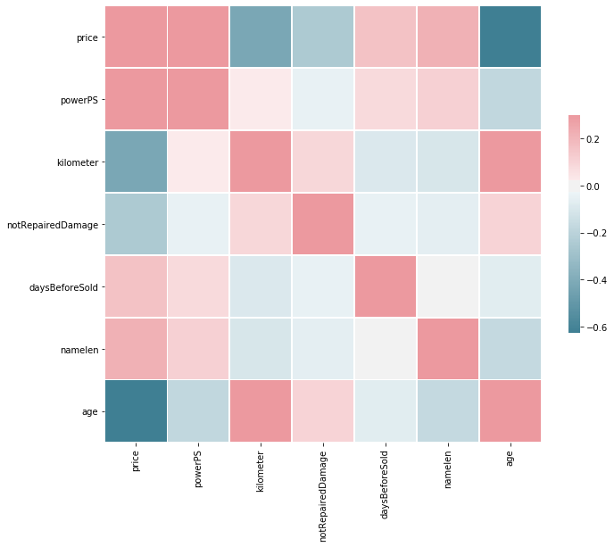

```python
# Compute the correlation matrix
corr = dfim.corr()

# Set up the matplotlib figure
f, ax = plt.subplots(figsize=(11, 9))

# Generate a custom diverging colormap
cmap = sns.diverging_palette(220, 10, as_cmap=True)

# Draw the heatmap with the mask and correct aspect ratio
sns.heatmap(corr, cmap=cmap, vmax=.3, center=0,
            square=True, linewidths=.5, cbar_kws={"shrink": .5})
```

## Linear regression

We decided to start with linear regression in order to have a base to compare other methods.

First we wanted to check OLS Regression Results to see how every independent variable effecting price.

```python
mod = smf.ols(formula='price ~ vehicleType + gearbox + powerPS + kilometer + fuelType + model + brand + notRepairedDamage', data=dfim)
res = mod.fit()
res.summary()
```

OLS Regression Results

| Dep. Variable: | price | R-squared: | 0.700 |
| --- | --- | --- | --- |
| Model: | OLS | Adj. R-squared: | 0.700 |
| Method: | Least Squares | F-statistic: | 2188. |
| Date: | Wed, 10 Jun 2020 | Prob (F-statistic): | 0.00 |
| Time: | 01:38:11 | Log-Likelihood: | -2.5839e+05 |
| No. Observations: | 281853 | AIC: | 5.174e+05 |
| Df Residuals: | 281551 | BIC: | 5.206e+05 |
| Df Model: | 301 |  |  |
| Covariance Type: | nonrobust |  |  |

|  | coef | std err | t | P>\|t\| | [0.025 | 0.975] |
| --- | --- | --- | --- | --- | --- | --- |
| Intercept | 1.8468 | 0.064 | 28.686 | 0.000 | 1.721 | 1.973 |
| vehicleType[T.cabrio] | 0.1488 | 0.009 | 16.918 | 0.000 | 0.132 | 0.166 |
| vehicleType[T.coupe] | -0.1174 | 0.009 | -12.969 | 0.000 | -0.135 | -0.100 |
| vehicleType[T.limousine] | -0.0822 | 0.007 | -11.250 | 0.000 | -0.097 | -0.068 |
| vehicleType[T.others] | -0.2043 | 0.015 | -13.857 | 0.000 | -0.233 | -0.175 |
| vehicleType[T.small car] | -0.2414 | 0.008 | -31.538 | 0.000 | -0.256 | -0.226 |
| vehicleType[T.station wagon] | -0.0899 | 0.007 | -12.197 | 0.000 | -0.104 | -0.075 |
| vehicleType[T.suv] | 0.0374 | 0.012 | 3.194 | 0.001 | 0.014 | 0.060 |
| gearbox[T.manual] | -0.0569 | 0.003 | -16.577 | 0.000 | -0.064 | -0.050 |
| fuelType[T.diesel] | 0.1762 | 0.029 | 6.178 | 0.000 | 0.120 | 0.232 |
| fuelType[T.electric] | 0.9381 | 0.089 | 10.568 | 0.000 | 0.764 | 1.112 |
| fuelType[T.hybrid] | 0.3212 | 0.053 | 6.071 | 0.000 | 0.218 | 0.425 |
| fuelType[T.lpg] | -0.2961 | 0.030 | -9.885 | 0.000 | -0.355 | -0.237 |
| fuelType[T.others] | -0.4119 | 0.097 | -4.235 | 0.000 | -0.602 | -0.221 |
| fuelType[T.petrol] | -0.3833 | 0.029 | -13.440 | 0.000 | -0.439 | -0.327 |
| model[T.145] | 0.1046 | 0.119 | 0.881 | 0.379 | -0.128 | 0.337 |
| model[T.147] | 0.6549 | 0.058 | 11.245 | 0.000 | 0.541 | 0.769 |
| model[T.156] | -0.0202 | 0.058 | -0.348 | 0.728 | -0.134 | 0.094 |
| model[T.159] | 0.9781 | 0.067 | 14.514 | 0.000 | 0.846 | 1.110 |
| model[T.1_reihe] | 1.2092 | 0.049 | 24.612 | 0.000 | 1.113 | 1.306 |
| model[T.1er] | 1.3812 | 0.064 | 21.681 | 0.000 | 1.256 | 1.506 |
| model[T.200] | 1.1303 | 0.352 | 3.214 | 0.001 | 0.441 | 1.820 |
| model[T.2_reihe] | 1.1847 | 0.046 | 25.553 | 0.000 | 1.094 | 1.276 |
| model[T.300c] | 1.6323 | 0.076 | 21.471 | 0.000 | 1.483 | 1.781 |
| model[T.3_reihe] | 0.8219 | 0.046 | 17.835 | 0.000 | 0.732 | 0.912 |
| model[T.3er] | 0.8472 | 0.063 | 13.431 | 0.000 | 0.724 | 0.971 |
| model[T.4_reihe] | 0.5593 | 0.052 | 10.670 | 0.000 | 0.457 | 0.662 |
| model[T.500] | 1.8519 | 0.050 | 36.696 | 0.000 | 1.753 | 1.951 |
| model[T.5_reihe] | 1.2407 | 0.054 | 22.870 | 0.000 | 1.134 | 1.347 |
| model[T.5er] | 0.7099 | 0.063 | 11.203 | 0.000 | 0.586 | 0.834 |

[output cut: 272 more lines]

| Omnibus: | 28567.517 | Durbin-Watson: | 2.000 |
| --- | --- | --- | --- |
| Prob(Omnibus): | 0.000 | Jarque-Bera (JB): | 61264.757 |
| Skew: | -0.643 | Prob(JB): | 0.00 |
| Kurtosis: | 4.887 | Cond. No. | 8.01e+07 |

Warnings:  
[1] Standard Errors assume that the covariance matrix of the errors is correctly specified.  
[2] The condition number is large, 8.01e+07. This might indicate that there are  
strong multicollinearity or other numerical problems.

First step for linear regression prediction is preparing dependent and independent variables

```python
X = dfimdm.drop(['price'], axis='columns')
y = dfimdm.price
```

We decided to calculate predicted values and check the distribution of errors(differences between real and predicted values).

```python
X_train, X_test, y_train, y_testLR = train_test_split(X, y,test_size=0.35)

linreg = LinearRegression()
linreg.fit(X_train, y_train)
y_predLR = linreg.predict(X_test)
scoreLR = linreg.score(X_test, y_testLR)
print("Mean squared error:", np.sqrt(metrics.mean_squared_error(y_testLR, y_predLR)))
print("Prediction Accuracy:", scoreLR*100,"%")
```

[output not shown]

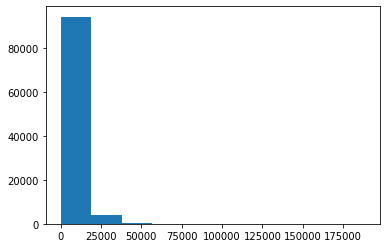

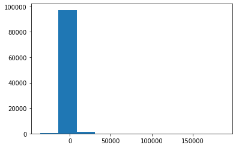

```python
plt.hist(np.exp(y_predLR))
plt.show()
plt.hist(np.exp(y_predLR) - np.exp(y_testLR.values))
plt.show()
```

In the first plot we can see how Linear Regression prediction looks like and in the second plot we can see that the difference between predicted and real prices.

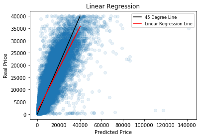

```python
plt.scatter(np.exp(y_predLR), np.exp(y_testLR.values), alpha=0.1)
plt.xlabel('Predicted Price')
plt.ylabel('Real Price')
m, b = np.polyfit(np.exp(y_predLR), np.exp(y_testLR.values), 1)
plt.plot([0, 40000], [0, 40000], color = 'black')
plt.plot(np.exp(y_testLR.values), m*np.exp(y_testLR.values) + b, 'red')
plt.legend(["45 Degree Line","Linear Regression Line"], fontsize = "small")
plt.title("Linear Regression")
plt.show()
```

Looks like with linear regression our estimates was correct 78% but it overshoot for some cars and cause outliers. Since we set 40000 as max in our dataset it should have stay there, but we can clearly see from plot that there are even predictions for 160000. Beside that the line is almost visible.

We decided to try Linear Regression with the data which we removed "model" from it.

```python
X = dmNoModel.drop(['price'], axis='columns')
y = dmNoModel.price

X_train, X_test, y_train, y_test = train_test_split(X, y,test_size=0.35)

linregNM = LinearRegression()
linregNM.fit(X_train, y_train)
y_predLRnm = linregNM.predict(X_test)
scoreLRnm = linregNM.score(X_test, y_test)
print("Mean squared error:", np.sqrt(metrics.mean_squared_error(y_test, y_predLRnm)))
print("Prediction Accuracy:", scoreLRnm*100,"%")
```

```
Mean squared error: 0.5431728112983774
Prediction Accuracy: 75.92429544770513 %
```

It looks like prediction accuracy decrease 3% we can clearly say that model is very important feature for our models. Having it in our models increases need to computational power and time it takes to run the code. But looks like it worths it.

## K-Nearest Neighbors

Next method we want to use is KNN. It is pretty hard to deal large dataset with KNN but we are thinking it might be successfull.

```python
dfimdm.head()
```

|  | price | powerPS | kilometer | notRepairedDamage | daysBeforeSold | namelen | age | vehicleType_bus | vehicleType_cabrio | vehicleType_coupe | ... | brand_saab | brand_seat | brand_skoda | brand_smart | brand_subaru | brand_suzuki | brand_toyota | brand_trabant | brand_volkswagen | brand_volvo |
| --- | --- | --- | --- | --- | --- | --- | --- | --- | --- | --- | --- | --- | --- | --- | --- | --- | --- | --- | --- | --- | --- |
| 2 | 9.190138 | 5.093750 | 125000 | 0 | 22 | 30 | 13 | 0 | 0 | 0 | ... | 0 | 0 | 0 | 0 | 0 | 0 | 0 | 0 | 0 | 0 |
| 3 | 7.313220 | 4.317488 | 150000 | 0 | 0 | 18 | 16 | 0 | 0 | 0 | ... | 0 | 0 | 0 | 0 | 0 | 0 | 0 | 0 | 1 | 0 |
| 4 | 8.188689 | 4.234107 | 90000 | 0 | 6 | 30 | 9 | 0 | 0 | 0 | ... | 0 | 0 | 1 | 0 | 0 | 0 | 0 | 0 | 0 | 0 |
| 5 | 6.476972 | 4.624973 | 150000 | 1 | 2 | 50 | 22 | 0 | 0 | 0 | ... | 0 | 0 | 0 | 0 | 0 | 0 | 0 | 0 | 0 | 0 |
| 6 | 7.696213 | 4.691348 | 150000 | 0 | 4 | 27 | 13 | 0 | 1 | 0 | ... | 0 | 0 | 0 | 0 | 0 | 0 | 0 | 0 | 0 | 0 |

5 rows × 310 columns

Firstly we wanted to work on the sample to see how KNN is dealing with our data. If it's worth to trouble.

After taking 50000 rows from our data we split them as 0.7 train and 0.3 test

```python
dfimdmsm = dfimdm.sample(50000)
# Create train and test set

train , test = train_test_split(dfimdmsm, test_size = 0.3)

x_train = train.drop('price', axis=1)
y_train = train['price']

x_test = test.drop('price', axis = 1)
y_test = test['price']
```

Since KNN is a Distance-Based algorithm we need to scale all variables otherwise KNN will not perform optimally.

We decided to scale them between 0 and 1.

```python
# Preprocessing – Scaling the features

scaler = MinMaxScaler(feature_range=(0, 1))

x_train_scaled = scaler.fit_transform(x_train)
x_train = pd.DataFrame(x_train_scaled)

x_test_scaled = scaler.fit_transform(x_test)
x_test = pd.DataFrame(x_test_scaled)
```

In order to decide how many neighbors we should have take we decided to check one by one what are the mean squared errors and what are the accuracy.

```python
# 50000 sample
# checking the error rate for different n_neighbors

rmse_val = [] #to store rmse values for different k
for K in range(10):
    K = K+1
    model = neighbors.KNeighborsRegressor(n_neighbors = K)

    model.fit(x_train, y_train)  #fit the model
    pred=model.predict(x_test) #make prediction on test set
    error = sqrt(mean_squared_error(y_test,pred)) #calculate rmse
    rmse_val.append(error) #store rmse values
    accur = metrics.r2_score(y_test.values, pred)
    print('RMSE value for k= ' , K , 'is:', error)
    print('Accuracy:', accur)
```

```
RMSE value for k=  1 is: 0.6049536263031672
Accuracy: 0.6999980498307028
RMSE value for k=  2 is: 0.5468598000477753
Accuracy: 0.7548499942517817
RMSE value for k=  3 is: 0.5296895487652233
Accuracy: 0.7700027109202482
RMSE value for k=  4 is: 0.5227594197965776
Accuracy: 0.7759816244541813
RMSE value for k=  5 is: 0.5199520640625209
Accuracy: 0.7783812391527545
RMSE value for k=  6 is: 0.5184923277704332
Accuracy: 0.7796238569228715
RMSE value for k=  7 is: 0.5190345307500124
Accuracy: 0.7791627080440598
RMSE value for k=  8 is: 0.5186760626109184
Accuracy: 0.7794676426548652
RMSE value for k=  9 is: 0.5200686170490425
Accuracy: 0.778281871440583
RMSE value for k=  10 is: 0.5222789774100678
Accuracy: 0.7763932037051288
```

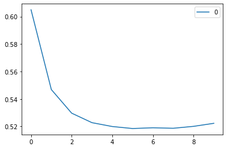

```python
# 50000
# k = 6
#plotting the rmse values against k values
curve = pd.DataFrame(rmse_val) #elbow curve
curve.plot()
```

```python
kf = KFold(n_splits=5, shuffle=True, random_state=random.randint(0,10000))
errors = []
accurs = []
for train, test in kf.split(dfimdmsm.index.values):
    x = dfimdmsm.drop('price', axis=1)
    y = dfimdmsm['price']
    x_train = x.iloc[train]
    y_train = y.iloc[train]

    x_test = x.iloc[test]
    y_test = y.iloc[test]

    scaler = MinMaxScaler(feature_range=(0, 1))

    x_train_scaled = scaler.fit_transform(x_train)
    x_train = pd.DataFrame(x_train_scaled)

    x_test_scaled = scaler.fit_transform(x_test)
    x_test = pd.DataFrame(x_test_scaled)

    model = neighbors.KNeighborsRegressor(n_neighbors = 6)

    model.fit(x_train, y_train)  #fit the model
    pred=model.predict(x_test) #make prediction on test set
    error = sqrt(mean_squared_error(y_test,pred)) #calculate rmse
    errors.append(error) #store rmse values
    accur = metrics.r2_score(y_test.values, pred)
    accurs.append(accur)
    print('Mean squared error:', error)
    print('Accuracy:', accur)
print('Average Mean squared error:', np.mean(error))
print('Average Accuracy:', np.mean(accur))
```

```
Mean squared error: 0.5165018393928361
Accuracy: 0.7860449749660823
Mean squared error: 0.5138397175930262
Accuracy: 0.7851171676672687
Mean squared error: 0.5188847355951102
Accuracy: 0.7819723825137893
Mean squared error: 0.5238604198020249
Accuracy: 0.7753907280544499
Mean squared error: 0.5097598957992157
Accuracy: 0.7880722080345804
Average Mean squared error: 0.5097598957992157
Average Accuracy: 0.7880722080345804
```

It looks like it worth the trouble. Even for 50000 sample it gave same result like linear regression(78%). So we decided to go for it with the all data.

```python
x = dfimdm.drop(['price'], axis='columns')
y = dfimdm.price
```

Since we are to fit and test with all data this time we were not be able to use Kfold or check what is the best n_neighbhors but we are guessing that 50 should be enough.

```python
x_train, x_test, y_train, y_test = train_test_split(x, y,test_size=0.35)


# Preprocessing – Scaling the features

scaler = MinMaxScaler(feature_range=(0, 1))

x_train_scaled = scaler.fit_transform(x_train)
x_train = pd.DataFrame(x_train_scaled)

x_test_scaled = scaler.fit_transform(x_test)
x_test = pd.DataFrame(x_test_scaled)

# classifier
model = neighbors.KNeighborsRegressor(n_neighbors = 50)

model.fit(x_train, y_train)  #fit the model
pred=model.predict(x_test) #make prediction on test set
error = sqrt(mean_squared_error(y_test,pred)) #calculate rmse
errors.append(error) #store rmse values
accur = metrics.r2_score(y_test.values, pred)
accurs.append(accur)
print('Mean squared error:', error)
print('Accuracy:', accur)
```

```
Mean squared error: 0.4971043315174484
Accuracy: 0.7978570670924983
```

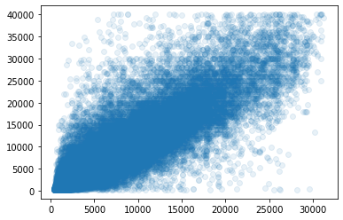

```python
plt.scatter(np.exp(pred), np.exp(y_test.values), alpha=0.1)
```

We see that KNN with 50 neighbors couldn't predict expensive cars accurately. It did more or less good job until 25k but after that start to not be accurate. Especially after 30k it did not work well at all.

After getting 79% of accuracy with KNN with 50 neighbors we suspect that maybe same neighbors number with 50000 sample would work better for all data.

```python
x = dfimdm.drop(['price'], axis='columns')
y = dfimdm.price

x_train, x_test, y_train, y_testknn = train_test_split(x, y,test_size=0.35)


# Preprocessing – Scaling the features

scaler = MinMaxScaler(feature_range=(0, 1))

x_train_scaled = scaler.fit_transform(x_train)
x_train = pd.DataFrame(x_train_scaled)

x_test_scaled = scaler.fit_transform(x_test)
x_test = pd.DataFrame(x_test_scaled)

# classifier
model = neighbors.KNeighborsRegressor(n_neighbors = 6)

model.fit(x_train, y_train)  #fit the model
pred=model.predict(x_test) #make prediction on test set
error = sqrt(mean_squared_error(y_testknn,pred)) #calculate rmse
accur = metrics.r2_score(y_testknn.values, pred)
print('Mean squared error:', error)
print('Accuracy:', accur*100,"%")
```

[output not shown]

Decreasing numbers of neighbors worked well and it increased accuracy from 79% to 83%. We wanted to plot the predictions and check how KNN worked.

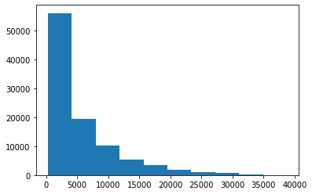

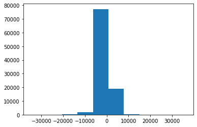

```python
plt.hist(np.exp(pred))
plt.show()
plt.hist(np.exp(pred) - np.exp(y_testknn))
plt.show()
```

In the first plot we can see how KNN prediction looks like and in the second plot we can see that the difference between predicted and real prices.

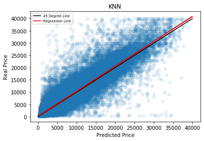

```python
plt.scatter(np.exp(pred), np.exp(y_testknn.values), alpha=0.1)
plt.xlabel('Predicted Price')
plt.ylabel('Real Price')
m, b = np.polyfit(np.exp(pred), np.exp(y_testknn.values), 1)
plt.plot([0, 40000], [0, 40000], color = 'black')
plt.plot(np.exp(y_testknn.values), m*np.exp(y_testknn.values) + b, 'red')
plt.legend(["45 Degree Line","Regression Line"], fontsize = "x-small")
plt.title("KNN")
plt.show()
```

This time looks like predictions became more accurate. Although we can see in general KNN under-price cars. Despite that it's very clear that it made better job than Linear Regression.

Before moving to the next method we want to check again how data without "model" would work with KNN.

```python
x = dmNoModel.drop(['price'], axis='columns')
y = dmNoModel.price
x_train, x_test, y_train, y_test = train_test_split(x, y,test_size=0.35)


# Preprocessing – Scaling the features

scaler = MinMaxScaler(feature_range=(0, 1))

x_train_scaled = scaler.fit_transform(x_train)
x_train = pd.DataFrame(x_train_scaled)

x_test_scaled = scaler.fit_transform(x_test)
x_test = pd.DataFrame(x_test_scaled)

# classifier
modelNM = neighbors.KNeighborsRegressor(n_neighbors = 6)

modelNM.fit(x_train, y_train)  #fit the model
predNM=modelNM.predict(x_test) #make prediction on test set
errorNM = sqrt(mean_squared_error(y_test,predNM)) #calculate rmse
accurNM = metrics.r2_score(y_test.values, predNM)
print('Mean squared error:', errorNM)
print('Accuracy:', accurNM)
```

```
Mean squared error: 0.4462644391027145
Accuracy: 0.8370413742371994
```

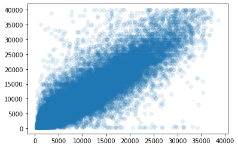

```python
plt.scatter(np.exp(predNM), np.exp(y_test.values), alpha=0.1)
```

Unlike Linear Regression in KNN data without "model" worked similiar. Since KNN working with distance we are thinking "model" was causing overfitting.

# Random Forest

Next method we used is random forest. Since we have plenty categories especially under brand and model we are thinking that random forest method will be great fit to our data.

#### Cross Validation (K-Fold)

We split our data into 5 parts, with KFold. And iterate it 5 times, every time test and train data was changing as follows:

**test**-train-train-train-train\ train-**test**-train-train-train\ train-train-**test**-train-train\ train-train-train-**test**-train\ train-train-train-train-**test**

We used this method to be able get more from our data and see if accuracy changes depending on the which part of data we are training and testing our model.

Since random forest is working with tree-based model we wanted to change the way we encode our data and try to make depth shorter.

```python
dfimrf = dfim.copy()
```

```python
for col in ['vehicleType', 'gearbox', 'model', 'fuelType', 'brand']:
    le = preprocessing.LabelEncoder()
    le.fit(dfimrf[col].unique())
    dfimrf[col] = le.transform(dfimrf[col])
```

```python
dfimrf.head()
```

|  | price | vehicleType | gearbox | powerPS | model | kilometer | fuelType | brand | notRepairedDamage | daysBeforeSold | namelen | age |
| --- | --- | --- | --- | --- | --- | --- | --- | --- | --- | --- | --- | --- |
| 2 | 9.190138 | 7 | 0 | 5.093750 | 118 | 125000 | 1 | 14 | 0 | 22 | 30 | 13 |
| 3 | 7.313220 | 5 | 1 | 4.317488 | 117 | 150000 | 6 | 37 | 0 | 0 | 18 | 16 |
| 4 | 8.188689 | 5 | 1 | 4.234107 | 102 | 90000 | 1 | 31 | 0 | 6 | 30 | 9 |
| 5 | 6.476972 | 3 | 1 | 4.624973 | 11 | 150000 | 6 | 2 | 1 | 2 | 50 | 22 |
| 6 | 7.696213 | 1 | 1 | 4.691348 | 8 | 150000 | 6 | 25 | 0 | 4 | 27 | 13 |

```python
# Create train and test set

kf = KFold(n_splits=5, shuffle=True, random_state=random.randint(0,10000))
ttscores = []
tnscores = []
errorsRF = []
k = 0
for train, test in kf.split(dfimrf.index.values):
    k += 1
    x = dfimrf.drop('price', axis=1)
    y = dfimrf['price']
    x_train = x.iloc[train]
    y_train = y.iloc[train]

    x_test = x.iloc[test]
    y_testrf = y.iloc[test]


    # classifier
    rfr = RandomForestRegressor()
    rfr.fit(x_train, y_train)
    tnscore = rfr.score(x_train, y_train)
    tnscores.append(tnscore)
    predRF = rfr.predict(x_test)
    ttscore = rfr.score(x_test, y_testrf)
    ttscores.append(ttscore)
    errorRF = sqrt(mean_squared_error(y_testrf,predRF)) #calculate rmse
    errorsRF.append(errorRF)

    print("Iteration:", k)
    print('Mean squared error:', errorRF)
    print("Score on train dataset:", tnscore*100,"%")
    print("Score on test dataset:", ttscore*100,"%")
print("------------------------------------------------------------")
print("Average score on train dataset:", np.mean(tnscores)*100,"%")
print("Average score on test dataset:", np.mean(ttscores)*100,"%")
print("Average mean squared error:", np.mean(errorsRF))
scoreRF = np.mean(ttscores)
predRF = rfr.predict(x_test)
```

```
Iteration: 1
Mean squared error: 0.3820645995609364
Score on train dataset: 98.17547238802267 %
Score on test dataset: 88.07437990798397 %
Iteration: 2
Mean squared error: 0.38516375201196273
Score on train dataset: 98.18266808609273 %
Score on test dataset: 87.8268330673091 %
Iteration: 3
Mean squared error: 0.3841497049536017
Score on train dataset: 98.18058271602435 %
Score on test dataset: 87.98161938435841 %
Iteration: 4
Mean squared error: 0.38220243996097386
Score on train dataset: 98.18183299214566 %
Score on test dataset: 88.11151608754373 %
Iteration: 5
Mean squared error: 0.3807380786848146
Score on train dataset: 98.16968832694684 %
Score on test dataset: 88.07147009215373 %
------------------------------------------------------------
Average score on train dataset: 98.17804890184645 %
Average score on test dataset: 88.01316370786978 %
Average mean squared error: 0.3828637150344578
```

The accuracy didn't differ much among the data in 5 iteration. Although 88% accuracy is impressive compare to Linear Regression and KNN methods. Let's see in the plots how predictions of the random forest model looks like.

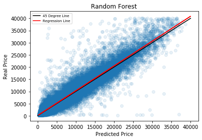

```python
plt.scatter(np.exp(predRF) ,np.exp(y_testrf), alpha=0.1)
plt.xlabel('Predicted Price')
plt.ylabel('Real Price')
m, b = np.polyfit(np.exp(predRF), np.exp(y_testrf), 1)
plt.plot([0, 40000], [0, 40000], color = 'black')
plt.plot(np.exp(y_testrf.values), m*np.exp(y_testrf.values) + b, 'red')
plt.legend(["45 Degree Line","Regression Line"], fontsize = "x-small")
plt.title("Random Forest")
plt.show()
```

It's clearly visible that this time model predict better. Of course there are some outliers like over and under pricing but in general the line became thiner and more visible.

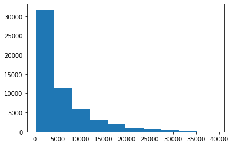

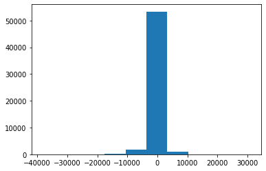

```python
plt.hist(np.exp(predRF))
plt.show()
plt.hist(np.exp(predRF) - np.exp(y_testrf.values))
plt.show()
```

In the first plot we can see how Random Forest prediction looks like and in the second plot we can see that the difference between predicted and real prices.

```python
dfimNoModelrf = dfimNoModel.copy()
for col in ['vehicleType', 'gearbox', 'fuelType', 'brand']:
    le = preprocessing.LabelEncoder()
    le.fit(dfimNoModelrf[col].unique())
    dfimNoModelrf[col] = le.transform(dfimNoModelrf[col])

xNM = dfimNoModelrf.drop(['price'], axis='columns')
yNM = dfimNoModelrf.price
```

```python
x_train, x_test, y_train, y_test = train_test_split(xNM, yNM,test_size=0.35)

rfrNM = RandomForestRegressor()
rfrNM.fit(x_train, y_train)
predRFNM = rfrNM.predict(x_test)
tnscoreNM = rfrNM.score(x_train, y_train)
ttscoreNM = rfrNM.score(x_test, y_test)

errorRFNM = sqrt(mean_squared_error(y_test,predRFNM))

print('Mean squared error:', errorRFNM)
print("Score on train dataset:", tnscoreNM*100,"%")
print("Score on test dataset:", ttscoreNM*100,"%")
```

```
Mean squared error: 0.3941554576475739
Score on train dataset: 98.04028522760329 %
Score on test dataset: 87.33483276126705 %
```

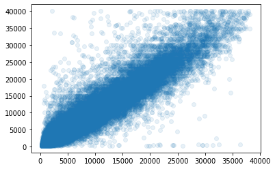

```python
plt.scatter(np.exp(predRFNM) ,np.exp(y_test.values), alpha=0.1)
```

Despite accuracy results looks same with and without "model" from plot above we can see that the line was thiner if it comes to predictions with "model". So we can say that thanks to model in the data our errors are smaller.

## Comparison of Methods and Conclusions

In this project we aimed to find the best regression model for used cars dataset to be able to predict used cars price.

Dataset was scraped with Scrapy from German eBay and there were some mistakes, duplications and outliers. As first step we removed them from the dataset and stayed with 79.9% of the original data.

There were 20 variables in the original dataset and we had to remove "dateCrawled", "postalCode", "abtest", "offerType", "nrOfPictures", and "seller" because they were not usefull for our purpose.\ We created new features:

- "daysBeforeSold" by using "dateCreated" and "lastSeen"
- "namelen" by using "name"
- "age" by using "yearOfRegistration"

After that we worked on missing values columnwise and impute what we could impute meaningfully and drop the rest. At the end we had 75.8% of the original data ready to use for price prediction.

We used log-transformation in price and powerPs and one hot encoding for categorical variables to be able to perform machine learning algorithms.

We used Linear Model, K Nearest Neighbor and Random Forest. The most successul one was Random Forest with 88.01% accuracy. Followed by KNN with 83.70% and the worst one was as expected Linear Regression with 78.67%.

### Linear Regression

Linear regression accuracy was 78% but it overshoot for some cars and cause outliers also underpricing was very common. Despite 40k is maximum price in our dataset Linear Regression model made some predictions even 160k. Beside that the line was very thick so those predictions were not good.\ We also tried to run Linear Regression without "model" variable to see the effects of it. It gave 3% less accuarcy on the dataset. For Linear Regression full data gave better results.

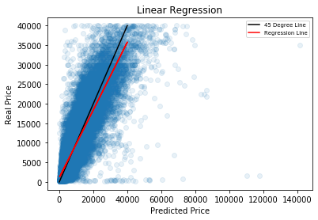

```python
plt.scatter(np.exp(y_predLR), np.exp(y_testLR.values), alpha=0.1)
plt.xlabel('Predicted Price')
plt.ylabel('Real Price')
m, b = np.polyfit(np.exp(y_predLR), np.exp(y_testLR.values), 1)
plt.plot([0, 40000], [0, 40000], color = 'black')
plt.plot(np.exp(y_testLR.values), m*np.exp(y_testLR.values) + b, 'red')
plt.legend(["45 Degree Line","Regression Line"], fontsize = "x-small")
plt.title("Linear Regression")
plt.show()
```

```python
print("Linear Regression prediction score(with model):", scoreLR*100, "%")
print("Linear Regression prediction score(without model):", scoreLRnm*100, "%")
```

```
Linear Regression prediction score(with model): 78.67175260741259 %
Linear Regression prediction score(without model): 75.92429544770513 %
```

### KNN

Since KNN is a Distance-Based algorithm we needed to start with scaling all variables. After data was ready next step was chosing how many neighbors to use. We decided to check one by one what are the mean squared errors and the accuracy in the sample we took from data.

After running test on the sample we run the KNN with 6 neighbors for all data, results were relatively better. And as usual we fit the KNN with data without "model" and this time results were similar.

Since predictions were same with the data with and without "model", below plot is with "model".

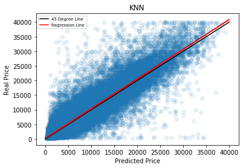

```python
plt.scatter(np.exp(pred), np.exp(y_testknn.values), alpha=0.1)
plt.xlabel('Predicted Price')
plt.ylabel('Real Price')
m, b = np.polyfit(np.exp(pred), np.exp(y_testknn.values), 1)
plt.plot([0, 40000], [0, 40000], color = 'black')
plt.plot(np.exp(y_testknn.values), m*np.exp(y_testknn.values) + b, 'red')
plt.legend(["45 Degree Line","Regression Line"], fontsize = "x-small")
plt.title("KNN")
plt.show()
```

```python
print("KNN prediction score(with model):", accur*100, "%")
print("KNN prediction score(without model):", accurNM*100, "%")
```

```
KNN prediction score(with model): 83.614344268346 %
KNN prediction score(without model): 83.70413742371994 %
```

### Random Forest

Last method we used was Random forest. We changed the way of encoding the data for this method in order to decrease depth of trees shorter.

We used KFold method to split our data to be able get more from it and see if accuracy changes depending on the which part of data we are training and testing our model.

Results were better than Linear Regression and KNN.

And as usual we fit the KNN with data without "model" and this time accuracy results were same. Although in without "model" prediction plot we realized that the line was thicker than predictions with "model". So we can say that thanks to "model" in the data errors were smaller. For Random Forest data with "model" was better that's why as a final plot belongs to that.

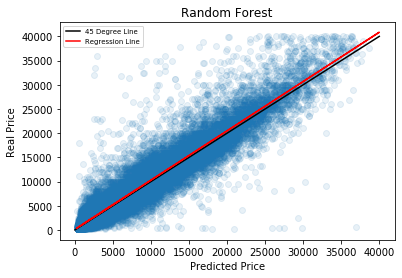

```python
plt.scatter(np.exp(predRF) ,np.exp(y_testrf), alpha=0.1)
plt.xlabel('Predicted Price')
plt.ylabel('Real Price')
m, b = np.polyfit(np.exp(predRF), np.exp(y_testrf), 1)
plt.plot([0, 40000], [0, 40000], color = 'black')
plt.plot(np.exp(y_testrf.values), m*np.exp(y_testrf.values) + b, 'red')
plt.legend(["45 Degree Line","Regression Line"], fontsize = "x-small")
plt.title("Random Forest")
plt.show()
```

```python
print("Random Forest prediction score(with model):", scoreRF*100, "%")
print("Random Forest prediction score(without model):", ttscoreNM*100, "%")
```

```
Random Forest prediction score(with model): 88.01316370786978 %
Random Forest prediction score(without model): 87.33483276126705 %
```

Random Forest(with model) gave the best result 88%. For this dataset Random Forest perform in a best way in prediction and also computational power and time. We are thinking that it is the best fit among all 3 methods we used.

Despite the quality of the dataset we believe that results were pretty outstanding.